# Medical Insurance Cost Analytics

Statistical analysis of the MAT 429 educational dataset

Author

Youssef Rafik

## Executive summary

Recorded smoking status had the strongest group association. The median charge was $34,456.35 among smokers and $7,345.41 among nonsmokers. Age had the strongest of the three rank correlations. For sex and region, mean and rank tests addressed different questions and led to different strength of evidence.

## Dataset and data quality

The educational CSV has 1,338 observations and seven fields. Age, BMI and covered children are numeric characteristics. Sex, smoking status and region are categorical. Recorded billed charges are the outcome. Validation found 0 missing values and 1 exact repeat beyond the first occurrence. The pooled 1.5 × IQR rule flagged 139 observations. All records were retained in the main analysis.

## Questions and statistical methodology

1. Do charges differ by smoking status?
2. Do charges differ across U.S. regions?
3. Do charges differ by sex?
4. Are age, BMI and number of covered children associated with charges?

The rank tests use a two-sided asymptotic approximation, with tie correction and continuity correction for rank-sum. Kruskal–Wallis uses a tie-corrected omnibus statistic. The six exploratory regional comparisons use Bonferroni adjustment. Welch t-tests compare means. Ordinary ANOVA assumes equal group variances, and Welch ANOVA allows them to differ. Spearman describes monotonic association using average ranks. Observations are treated as independent.

## Exploratory analysis

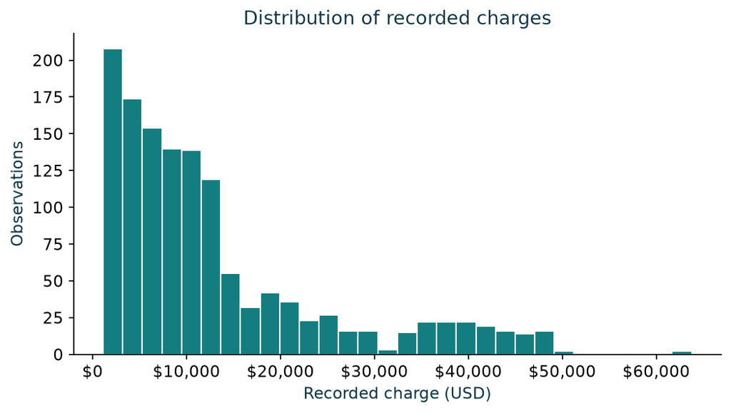

The pooled charge distribution has a long upper tail.

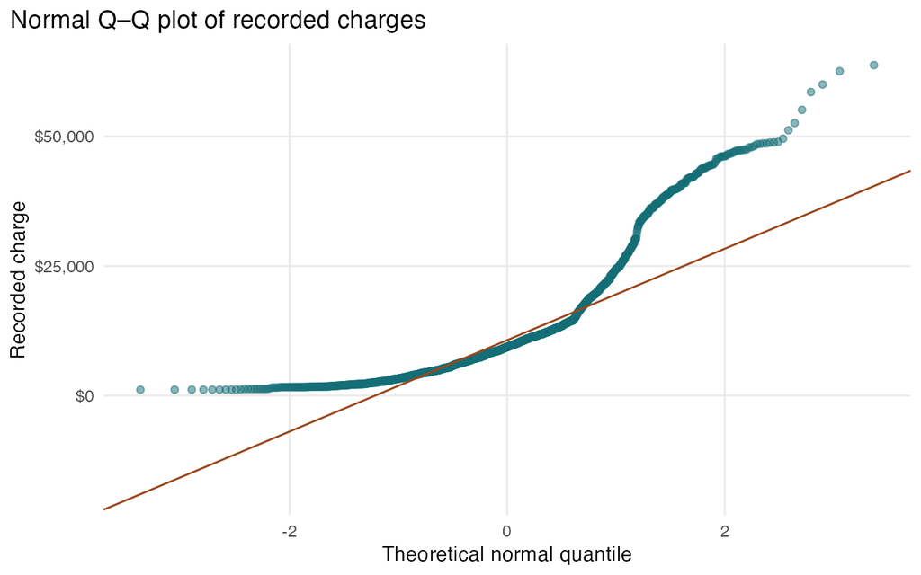

The normal Q–Q diagnostic shows substantial upper-tail deviation.

| Group | n | Mean | Median | SD | Skew | Tail n | Smoking share |
| --- | --- | --- | --- | --- | --- | --- | --- |
| no | 1064 | 8434.268 | 7345.405 | 5993.782 | 1.538 | 3 | 0 |
| yes | 274 | 32050.232 | 34456.348 | 11541.547 | 0.128 | 136 | 1 |

## Hypothesis tests

| Test | Statistic | p-value |
| --- | --- | --- |
| shapiro | 0.8147 | 1.151e-36 |
| wilcoxon_smoker | 7403.0000 | 5.270e-130 |
| welch_smoker | -32.7519 | 5.889e-103 |
| wilcoxon_sex | 221304.0000 | 0.72865 |
| welch_sex | -2.1009 | 0.03584 |
| kruskal_region | 4.7342 | 0.19233 |
| anova_region | 2.9696 | 0.03089 |
| welch_region | 2.6081 | 0.05059 |
| region_northeast_northwest | 56410.0000 | 0.69270 |
| region_northeast_southeast | 60447.0000 | 1.00000 |
| region_northeast_southwest | 57619.0000 | 0.22494 |
| region_northwest_southeast | 56961.0000 | 1.00000 |
| region_northwest_southwest | 53967.0000 | 1.00000 |
| region_southeast_southwest | 62413.0000 | 1.00000 |
| spearman_age | 0.5344 | 1.131e-99 |
| spearman_bmi | 0.1194 | 1.193e-05 |
| spearman_children | 0.1333 | 9.847e-07 |

## Effect sizes and uncertainty

The directed comparisons are smokers minus nonsmokers and male minus female. Intervals are seeded 95% percentile bootstrap intervals from 2,000 draws, resampled within each group or as paired rows for correlations. Regional rank eta-squared is a point estimate. These intervals are marginal and conditional on the observed sampling structure.

| Effect | Estimate | Lower | Upper |
| --- | --- | --- | --- |
| smoker_rank_biserial | 0.9492 | 0.9355 | 0.9618 |
| smoker_median_difference | 27110.9432 | 22048.2058 | 28865.6413 |
| smoker_mean_difference | 23615.9635 | 22231.7297 | 25064.9784 |
| sex_rank_biserial | 0.0110 | -0.0475 | 0.0759 |
| sex_median_difference | -43.3467 | -969.7490 | 1232.3732 |
| sex_mean_difference | 1387.1723 | 114.1779 | 2747.0356 |
| region_rank_eta_squared | 0.0013 | NA | NA |
| spearman_age | 0.5344 | 0.4827 | 0.5844 |
| spearman_bmi | 0.1194 | 0.0645 | 0.1717 |
| spearman_children | 0.1333 | 0.0803 | 0.1859 |

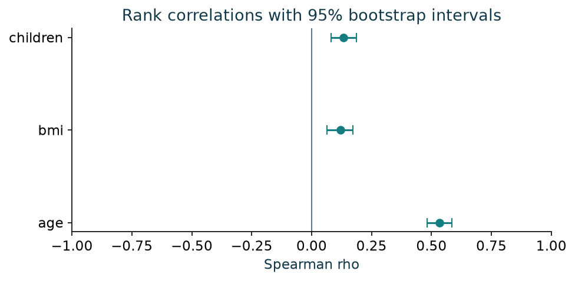

Age has the strongest Spearman correlation of the three variables.

## Why Parametric and Nonparametric Tests Disagree

| Group | n | Mean | Median | SD | Skew | Tail n | Smoking share |
| --- | --- | --- | --- | --- | --- | --- | --- |
| female | 662 | 12569.58 | 9412.962 | 11128.70 | 1.729 | 50 | 0.174 |
| male | 676 | 13956.75 | 9369.616 | 12971.03 | 1.336 | 89 | 0.235 |

| Group | n | Mean | Median | SD | Skew | Tail n | Smoking share |
| --- | --- | --- | --- | --- | --- | --- | --- |
| northeast | 324 | 13406.39 | 10057.652 | 11255.80 | 1.493 | 28 | 0.207 |
| northwest | 325 | 12417.58 | 8965.796 | 11072.28 | 1.682 | 20 | 0.178 |
| southeast | 364 | 14735.41 | 9294.132 | 13971.10 | 1.251 | 57 | 0.250 |
| southwest | 325 | 12346.94 | 8798.593 | 11557.18 | 1.682 | 34 | 0.178 |

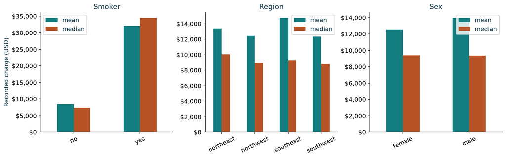

Mean-to-median gaps vary across sex and regional groups.

The sex groups have nearly equal medians despite higher mean charges in the male group. Their different tail counts, spreads and smoking proportions help describe the divergence between those estimands. The southeast has the highest regional mean and SD, while the northeast has the highest median. A mean difference can be driven by upper-tail magnitudes, while a rank test depends on how observations are ordered. The Welch regional p-value is close to 0.05 and illustrates how equal-variance assumptions affect the benchmark.

|  | Scenario | n | Sex rank | Sex Welch | Region rank | Region ANOVA | Region Welch |
| --- | --- | --- | --- | --- | --- | --- | --- |
| 1 | All observations | 1338 | 0.7287 | 0.0358 | 0.1923 | 0.0309 | 0.0506 |
| 6 | Exact repeats collapsed | 1337 | 0.6945 | 0.0336 | 0.2016 | 0.0328 | 0.0535 |
| 11 | Outside pooled IQR fences excluded | 1199 | 0.0998 | 0.3998 | 0.0134 | 0.0177 | 0.0116 |
| 16 | Upper 5% capped at pooled cutoff | 1338 | 0.7226 | 0.0342 | 0.1876 | 0.0382 | 0.0552 |

The broad pattern persisted after collapsing the repeat and after capping charges at the 95th percentile. Excluding pooled-fence exceedances attenuated the sex mean result and strengthened the regional rank result. Exclusion changes the analytic cohort and describes a different subset. These checks are exploratory.

## Limitations and conclusion

Sampling, observation dates and the independence of records cannot be verified. Confounding and omitted variables limit interpretation of these unadjusted associations. The recorded sex labels and broad region labels also limit fairness and generalizability assessments. The data provide an educational example of comparing distributional and mean-based evidence. They cannot establish causation or support operational insurance decisions.